# Development of strategies to identify and expand asset customers

## Introduction

The AllLife Bank has had success in the last year in converting 9% of their liability customer base to asset customers. This has enabled the bank to generate additional revenue through interest on the loans. Based on this healthy conversion rate, it is useful to develop strategies to identify which of the liability customers are likely to become asset customers with the help of targeted marketing, while retaining them as liability customers also.

Background: The bank's liability customers are customers who have deposits in the bank and they are the largest group of customers for the bank. The asset customers are a small segment who borrow personal loans.

### Objective

1. Identifying liability customers who are likely to get a personal loan from the bank
2. Generating insights into the characteristics of the customers that would put them in asset customer group

### Data Information/Variables

**ID** - customer ID  
**Age** - age of the customer (completed years)  
**Experience** - number of years of professional service  
**Income** - annual income of customer (in thousand dollars)  
**ZIPCode** - zip code for home address  
**Family** - the number of people in the household for the family  
**CCAvg** - average spending on credit cards per month (in thousand dollars)  
**Education** - level of education (1. Undergrad, 2.Graduate, 3. Advanced/Professional)  
**Mortgage** - Value of house mortgage (in thousand dollars)  
**Personal_Loan** - Yes/No data in the form of 1/0, did the customer accept personal loan offered in last campaign  
**Securities_Account** - Yes/No data in the form of 1/0, does customer have securities account in bank  
**CD_Account** - Yes/No data in the form of 1/0, does customer have a certificate of deposit (CD) with the bank?  
**Online** - Yes/No data in the form of 1/0, do customers use internet banking facilities?  
**CreditCard** - Yes/No data in the form of 1/0, does customer use credit card issued by a bank that is not AllLife Bank?

### The analysis below has the following sections:

1. Loading and importing packages
2. Removing warnings from python notebooks
3. Loading the dataset
4. Preview of the dataset
5. Descriptive statistics for the dataset
6. Exploratory Data Analysis - univariate, bivariate and multivariate analysis
7. Data preprocessing - missing value treatment, outlier treatment, feature engineering,  
   preparation of data for modeling, splitting the data
8. **Logistic Regression Model** - model building, interpretation of coefficients, performance  
   evaluation, model improvement
9. **Decision Tree Model** - model building, identifying key variables, performance evaluation  
   model improvement
10. Insights and recommendations for the marketing department

### 1. Loading and importing packages

```python
# Packages that will be used here include: numpy, pandas, matplotlib, seaborn, sklearn
# Package uszipcode was also used

# Import the necessary packages
import numpy as np
import pandas as pd
import matplotlib.pyplot as plt
import seaborn as sns

# Import for conversion of ZIPCode to county data
import uszipcode
from uszipcode import SearchEngine

search = SearchEngine()

# For feature selection for logistic regression
from mlxtend.feature_selection import SequentialFeatureSelector as SFS

# To plot the performance with addition of each feature
from mlxtend.plotting import plot_sequential_feature_selection as plot_sfs

sns.set(color_codes=True)  # For background of the graphs
%matplotlib inline

# For previewing the data, the columns can be set to limit of None and 100 for the rows.
pd.set_option("display.max_columns", None)
pd.set_option("display.max_rows", 100)

# Below is for logistic regression model metrics,splitting the observations for train/test
from sklearn.model_selection import train_test_split

# Below is for Logistic Regression models
from sklearn.linear_model import LogisticRegression

# Below is for decision tree models
from sklearn.tree import DecisionTreeClassifier
from sklearn import tree

# For hyperparameter tuning
from sklearn.model_selection import GridSearchCV

# To get diferent metric scores for logistic regression and decision trees
from sklearn.metrics import (
    f1_score,
    accuracy_score,
    recall_score,
    precision_score,
    confusion_matrix,
    plot_confusion_matrix,
    make_scorer,
    roc_auc_score,
    precision_recall_curve,
    roc_curve,
)

# For automatic structuring/beautification of the python notebook
%load_ext nb_black
```

```
The nb_black extension is already loaded. To reload it, use:
  %reload_ext nb_black
```

### 2. Removing warnings from python notebook

```python
# Removing warnings from the notebook
import warnings

warnings.filterwarnings("ignore")
```

### 3. Loading the dataset

```python
# The dataset is stored in a CSV file and we want to read it into a pandas dataframe
loanData = pd.read_csv("Loan_Modelling.csv", index_col=0)
# We are using index_col = 0, otherwise the dataframe had the first column as an index, and then"ID" as an index again.
# Using index_col = 0 will make the dataframe have "ID" as the first column.
print(f"The dataframe has {loanData.shape[0]} rows and {loanData.shape[1]} columns.")
# Using f-string to print the statement for performance reasons
```

```
The dataframe has 5000 rows and 13 columns.
```

### 4. Previewing the dataset

```python
# Preview of the first 5 rows of the dataset
loanData.head()
```

| ID | Age | Experience | Income | ZIPCode | Family | CCAvg | Education | Mortgage | Personal_Loan | Securities_Account | CD_Account | Online | CreditCard |
| --- | --- | --- | --- | --- | --- | --- | --- | --- | --- | --- | --- | --- | --- |
| 1 | 25 | 1 | 49 | 91107 | 4 | 1.6 | 1 | 0 | 0 | 1 | 0 | 0 | 0 |
| 2 | 45 | 19 | 34 | 90089 | 3 | 1.5 | 1 | 0 | 0 | 1 | 0 | 0 | 0 |
| 3 | 39 | 15 | 11 | 94720 | 1 | 1.0 | 1 | 0 | 0 | 0 | 0 | 0 | 0 |
| 4 | 35 | 9 | 100 | 94112 | 1 | 2.7 | 2 | 0 | 0 | 0 | 0 | 0 | 0 |
| 5 | 35 | 8 | 45 | 91330 | 4 | 1.0 | 2 | 0 | 0 | 0 | 0 | 0 | 1 |

#### Observation

```python
# Preview of 10 random rows of the dataset
# To see random 10 rows, numpy's random seed was used.
# Putting random.seed to be 1 will return the same random 10 rows everytime we execute the code.
np.random.seed(1)
loanData.sample(n=10)
# The Reason we want to return random rows is so that we can see  the typical values from a random sample.
```

| ID | Age | Experience | Income | ZIPCode | Family | CCAvg | Education | Mortgage | Personal_Loan | Securities_Account | CD_Account | Online | CreditCard |
| --- | --- | --- | --- | --- | --- | --- | --- | --- | --- | --- | --- | --- | --- |
| 2765 | 31 | 5 | 84 | 91320 | 1 | 2.9 | 3 | 105 | 0 | 0 | 0 | 0 | 1 |
| 4768 | 35 | 9 | 45 | 90639 | 3 | 0.9 | 1 | 101 | 0 | 1 | 0 | 0 | 0 |
| 3815 | 34 | 9 | 35 | 94304 | 3 | 1.3 | 1 | 0 | 0 | 0 | 0 | 0 | 0 |
| 3500 | 49 | 23 | 114 | 94550 | 1 | 0.3 | 1 | 286 | 0 | 0 | 0 | 1 | 0 |
| 2736 | 36 | 12 | 70 | 92131 | 3 | 2.6 | 2 | 165 | 0 | 0 | 0 | 1 | 0 |
| 3923 | 31 | 4 | 20 | 95616 | 4 | 1.5 | 2 | 0 | 0 | 0 | 0 | 1 | 0 |
| 2702 | 50 | 26 | 55 | 94305 | 1 | 1.6 | 2 | 0 | 0 | 0 | 0 | 1 | 0 |
| 1180 | 36 | 11 | 98 | 90291 | 3 | 1.2 | 3 | 0 | 0 | 1 | 0 | 0 | 1 |
| 933 | 51 | 27 | 112 | 94720 | 3 | 1.8 | 2 | 0 | 0 | 1 | 1 | 1 | 1 |
| 793 | 41 | 16 | 98 | 93117 | 1 | 4.0 | 3 | 0 | 0 | 0 | 0 | 0 | 1 |

#### Observation

The random rows do not show any missing values, or NaNs. The ZipCode column is mostly showing 5 digits, which corresponds to US addresses. For the Mortgage column, there are number of rows that are 0 - this could mean that some of the customers do not own houses, or the data is incomplete. The columns Personal_Loan, Securities_Account, CD_Account, Online, CreditCard are in the form of Yes/No data where 1 is most likely to correspond with Yes, and 0 means a negative answer.This will facilitate their treatment as categorical variables for the analysis.

```python
loanData.info()
```

```
<class 'pandas.core.frame.DataFrame'>
Int64Index: 5000 entries, 1 to 5000
Data columns (total 13 columns):
 #   Column              Non-Null Count  Dtype
---  ------              --------------  -----
 0   Age                 5000 non-null   int64
 1   Experience          5000 non-null   int64
 2   Income              5000 non-null   int64
 3   ZIPCode             5000 non-null   int64
 4   Family              5000 non-null   int64
 5   CCAvg               5000 non-null   float64
 6   Education           5000 non-null   int64
 7   Mortgage            5000 non-null   int64
 8   Personal_Loan       5000 non-null   int64
 9   Securities_Account  5000 non-null   int64
 10  CD_Account          5000 non-null   int64
 11  Online              5000 non-null   int64
 12  CreditCard          5000 non-null   int64
dtypes: float64(1), int64(12)
memory usage: 546.9 KB
```

#### Observation

There are no missing values in this dataset as there are 5000 non-null values for each column. All the columns are either of the type int64 or float 64.

```python
# Finding the sum total of missing values in each of the columns
loanData.isnull().sum().sort_values(ascending=False)
```

```
CreditCard            0
Online                0
CD_Account            0
Securities_Account    0
Personal_Loan         0
Mortgage              0
Education             0
CCAvg                 0
Family                0
ZIPCode               0
Income                0
Experience            0
Age                   0
dtype: int64
```

#### Observation

This confirms our earlier observation that none of the columns have any missing values or null values.

### Descriptive Summary Statistics for the dataset

```python
# Before starting preprocessing, a look at summary statistics
loanData.describe(include="all").T  # taking transpose since it is easier to view
```

|  | count | mean | std | min | 25% | 50% | 75% | max |
| --- | --- | --- | --- | --- | --- | --- | --- | --- |
| Age | 5000.0 | 45.338400 | 11.463166 | 23.0 | 35.0 | 45.0 | 55.0 | 67.0 |
| Experience | 5000.0 | 20.104600 | 11.467954 | -3.0 | 10.0 | 20.0 | 30.0 | 43.0 |
| Income | 5000.0 | 73.774200 | 46.033729 | 8.0 | 39.0 | 64.0 | 98.0 | 224.0 |
| ZIPCode | 5000.0 | 93169.257000 | 1759.455086 | 90005.0 | 91911.0 | 93437.0 | 94608.0 | 96651.0 |
| Family | 5000.0 | 2.396400 | 1.147663 | 1.0 | 1.0 | 2.0 | 3.0 | 4.0 |
| CCAvg | 5000.0 | 1.937938 | 1.747659 | 0.0 | 0.7 | 1.5 | 2.5 | 10.0 |
| Education | 5000.0 | 1.881000 | 0.839869 | 1.0 | 1.0 | 2.0 | 3.0 | 3.0 |
| Mortgage | 5000.0 | 56.498800 | 101.713802 | 0.0 | 0.0 | 0.0 | 101.0 | 635.0 |
| Personal_Loan | 5000.0 | 0.096000 | 0.294621 | 0.0 | 0.0 | 0.0 | 0.0 | 1.0 |
| Securities_Account | 5000.0 | 0.104400 | 0.305809 | 0.0 | 0.0 | 0.0 | 0.0 | 1.0 |
| CD_Account | 5000.0 | 0.060400 | 0.238250 | 0.0 | 0.0 | 0.0 | 0.0 | 1.0 |
| Online | 5000.0 | 0.596800 | 0.490589 | 0.0 | 0.0 | 1.0 | 1.0 | 1.0 |
| CreditCard | 5000.0 | 0.294000 | 0.455637 | 0.0 | 0.0 | 0.0 | 1.0 | 1.0 |

#### Observations

```python
# Descriptive statistics on categorical variables
# Let us take a look at how many of the current customers took a personal loan in the last campaign
personalLoanCount = pd.crosstab(index=loanData["Personal_Loan"], columns="count")
personalLoanCount
percentLoanYes = (personalLoanCount.loc[1] / (loanData.shape[0])) * 100
percentLoanYes
print(f"The percentage of customers took the personal loan is {float(percentLoanYes)}.")
```

```
The percentage of customers took the personal loan is 9.6.
```

#### Observations

When targeted by the marketing department in the last campaign, 480 i.e. 9.6% liability customers became asset customers (meaning they took a personal loan from the bank).

```python
EducationCount = pd.crosstab(index=loanData["Education"], columns="count")
EducationCount
```

| col_0 Education | count |
| --- | --- |
| 1 | 2096 |
| 2 | 1403 |
| 3 | 1501 |

#### Observations

For 'Education', 1 signifies undergraduate education level, 2 is graduate, and 3 is advanced or professional degree. From above, we can see that the biggest group of customers have an undergraduate degree, the 2nd largest group is advanced or professional degree and the last group with 1403 customers have a graduate degree.

```python
FamilyCount = pd.crosstab(index=loanData["Family"], columns="count")
FamilyCount
```

| col_0 Family | count |
| --- | --- |
| 1 | 1472 |
| 2 | 1296 |
| 3 | 1010 |
| 4 | 1222 |

#### Observations

All the four groups in family are close to each other in total counts. However, singles are slightly larger in number than couples.

```python
SecuritiesCount = pd.crosstab(index=loanData["Securities_Account"], columns="count")
SecuritiesCount
```

| col_0 Securities_Account | count |
| --- | --- |
| 0 | 4478 |
| 1 | 522 |

#### Observations

We can assume that '0' stands for not having a securities account in the bank. The majority of customers did not have a securities account in the bank.

```python
CDCount = pd.crosstab(index=loanData["CD_Account"], columns="count")
CDCount
```

| col_0 CD_Account | count |
| --- | --- |
| 0 | 4698 |
| 1 | 302 |

#### Observations

```python
OnlineCount = pd.crosstab(index=loanData["Online"], columns="count")
OnlineCount
```

| col_0 Online | count |
| --- | --- |
| 0 | 2016 |
| 1 | 2984 |

#### Observations

The number of customers who did mobile/online banking was slightly larger than the group that did not do mobile/online banking.

```python
CreditCardCount = pd.crosstab(index=loanData["CreditCard"], columns="count")
CreditCardCount
```

| col_0 CreditCard | count |
| --- | --- |
| 0 | 3530 |
| 1 | 1470 |

### 6. Exploratory Data Analysis (EDA) - univariate, bivariate and multivariate analysis

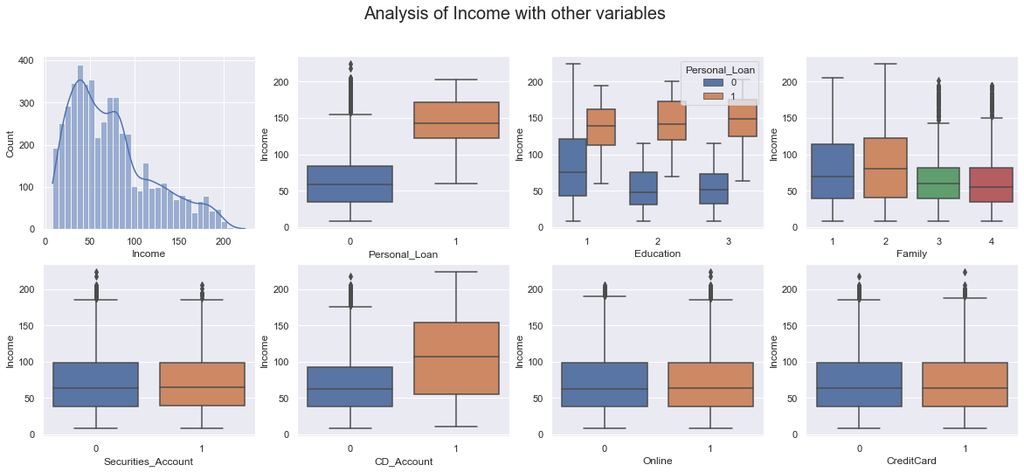

```python
# Univariate and bivariate analysis
# We can start with analysis of 'Income' - histogram and box plots of 'Income' versus 'Personal_Loan','Family'
#'Education','Securities_Account','CD_Account','Online' and 'CreditCard'
#'Income' here is the continous variable
# While variables such as 'Personal_Loan' have type int64, they have values of 0 and 1, so we can treat it as a categorical variable.
# Display histogram and boxplots for Income analysis
# Make a grid of 2 rows and 4 columns
fig, axs = plt.subplots(2, 4, figsize=(20, 8))
# Put a figure title
fig.suptitle("Analysis of Income with other variables", fontsize=20)
# Histogram of Income variable
sns.histplot(ax=axs[0, 0], data=loanData, x="Income", kde=True)
# Box plot for Personal_Loan versus Income
sns.boxplot(
    ax=axs[0, 1], data=loanData, x=loanData["Personal_Loan"], y=loanData["Income"]
)
# The remaining boxplots have Income on the y-axis, and the rest of the variables on the x-axis (so treated as categories)
sns.boxplot(
    ax=axs[0, 2],
    data=loanData,
    x=loanData["Education"],
    y=loanData["Income"],
    hue=loanData["Personal_Loan"],
)
sns.boxplot(ax=axs[0, 3], data=loanData, x=loanData["Family"], y=loanData["Income"])
sns.boxplot(
    ax=axs[1, 0], data=loanData, x=loanData["Securities_Account"], y=loanData["Income"]
)
sns.boxplot(ax=axs[1, 1], data=loanData, x=loanData["CD_Account"], y=loanData["Income"])
sns.boxplot(ax=axs[1, 2], data=loanData, x=loanData["Online"], y=loanData["Income"])
sns.boxplot(ax=axs[1, 3], data=loanData, x=loanData["CreditCard"], y=loanData["Income"])
# We put semicolons to supress the axis output
```

#### Observations

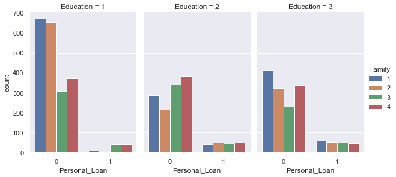

```python
# Analysis using both numerical and categorical variables
g = sns.catplot(
    x="Personal_Loan",
    hue="Family",
    col="Education",
    data=loanData,
    kind="count",
    height=4,
    aspect=0.7,
)
```

#### Observations

The customers who took a personal loan are less in number as compared to people who did not take a personal loan for every education level. This may be due to the fact that only 9.6% of customers took a personal loan, while 90.4% customers fall into the bucket that did not take a personal loan.

For undergraduate level, customers who had households comprising of 3 and 4 people and took a personal loan outnumbered the customers who are single or have 2 members in their family. This trend does not hold for customers who had a graduate degree or advanced/professional degrees. However, increasing the sample size of the customers who took a personal loan (which may take time as the campaign started last year) will be more useful for seeing the trends in education.

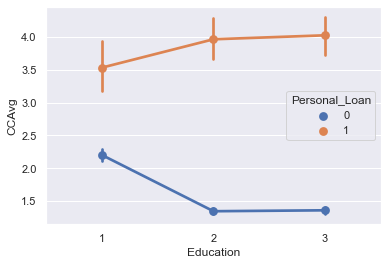

```python
# Analysis using both numerical and categorical variables
sns.pointplot(x="Education", y="CCAvg", hue="Personal_Loan", data=loanData)
plt.show()
```

#### Observations

CCAvg is the average amount that customers spend per month for credit cards. There is significant difference between customers who took a personal loan, and those who did not at every education level. Overall, customers who took a personal loan had a higher spending on average for credit cards per month. We can also see that the error bars for personal loan group are greater than the ones for those groups who did not take a personal loan. This can be attributed to the small sample size for the customers who took a personal loan.

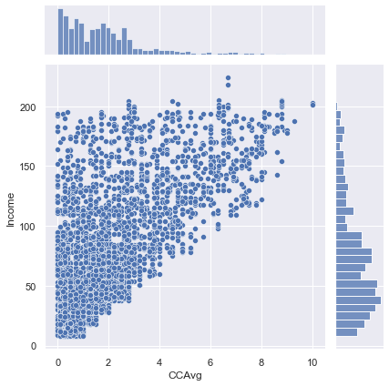

```python
# Bivariate analysis on age and income
sns.jointplot(loanData["CCAvg"], loanData["Income"])
```

#### Observations

CCAvg has number of 0 values, but these may indicate that the customers do not have a credit card with AllLife bank. Overall, higher the income of the customers, the more they spent on credit cards per month.

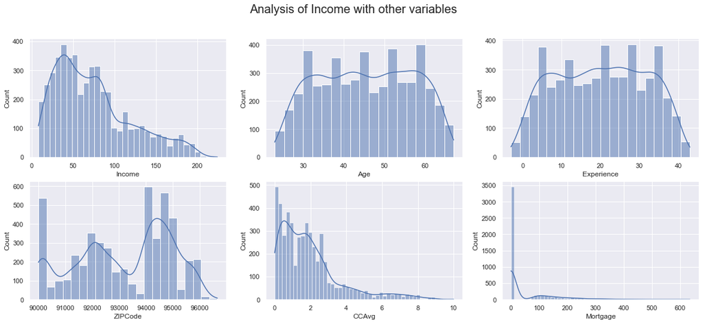

```python
# Univariate and bivariate analysis
# This section is for displaying the histograms for continous variables
# Make a grid of 2 rows and 4 columns
fig, axs = plt.subplots(2, 3, figsize=(20, 8))
# Put a figure title
fig.suptitle("Analysis of Income with other variables", fontsize=20)
# Histogram of Income variable
sns.histplot(ax=axs[0, 0], data=loanData, x="Income", kde=True)
sns.histplot(ax=axs[0, 1], data=loanData, x="Age", kde=True)
sns.histplot(ax=axs[0, 2], data=loanData, x="Experience", kde=True)
sns.histplot(ax=axs[1, 0], data=loanData, x="ZIPCode", kde=True)
sns.histplot(ax=axs[1, 1], data=loanData, x="CCAvg", kde=True)
sns.histplot(ax=axs[1, 2], data=loanData, x="Mortgage", kde=True)


# We put semicolons to supress the axis output
```

#### Observations

Income, CCAvg is a right skewed distribution as we inferred from the summary statistics also. Age and Experience are wide symmetric distributed graphs.Mortgage again has a high value of zero values - this may indicate that customers may be renting or do not have a mortgage with AllLife bank. For classification model building, we will converting Mortgage to a categorical value having 0 as not having a mortgage and a value of 1 to indicate that the customer had a mortgage.

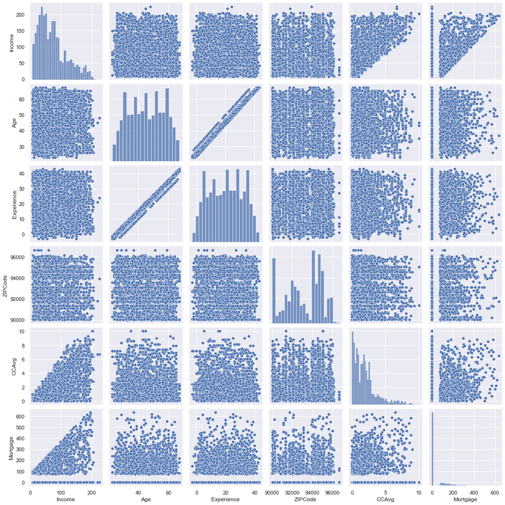

```python
# For the pairplot, we will skip the columns have binary data in the form of "0" and "1"
sns.pairplot(
    loanData,
    x_vars=["Income", "Age", "Experience", "ZIPCode", "CCAvg", "Mortgage"],
    y_vars=["Income", "Age", "Experience", "ZIPCode", "CCAvg", "Mortgage"],
)
```

#### Observations

We can see that Age and Experience are highly correlated. Income and CCAvg are right skewed. There is also some correlation between Income and CCAvg.

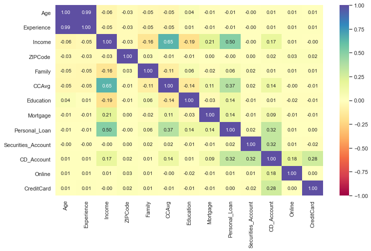

```python
plt.figure(figsize=(12, 7))
sns.heatmap(loanData.corr(), annot=True, vmin=-1, vmax=1, fmt=".2f", cmap="Spectral")
plt.show()
```

#### Observations

1. Age and Experience are highly correlated, since the correlation coefficient is 0.99. However, multicolinearity is not a big factor for classification problems as it is for linear regression analysis.
2. Income and CCAvg are strongly correlated (0.65) - indicating that higher the annunal income of the customers, more the spending amount on credit cards per month. Income has a moderate correlation with Personal_Loan (0.5) - meaning that customers who had higher incomes belonged to the group that took a personal loan from AllLife bank.
3. CCAvg had a weak correlation (0.37) with Personal_Loan.
4. There is some weak correlation between some variables such as CD_Account and Personal_Loan(0.32) and Securities_Account (0.32) and CreditCard (0.28).

### 7. Data pre-processing section

This section will have the following subsections:

1. Conversion of columns that have binary type data ('1','0') to categories
2. Evaulation of unique values for categories and continous variables
3. Conversion of Mortgage into a '1' and '0' column
4. Converting ZIPCode column into county column, and dropping ZIPCode
5. One hot encoding technique for county column
6. Converting negative values for Experience
7. Treatment of outliers

```python
# 7.1: Conversion of columns that have binary type data ('1','0') to categories
# We want to convert the columns to categories to facilitate pre-processing for example,
# treatment of outliers

# Before pre-processing,we want to copy the original dataframe to a new variable
loanDataprep = loanData.copy()

# Conversion into category
categorical_var = [
    "Personal_Loan",
    "Securities_Account",
    "CD_Account",
    "Online",
    "CreditCard",
]


for colname in categorical_var:
    loanDataprep[colname] = loanDataprep[colname].astype("category")

loanDataprep.info()
```

```
<class 'pandas.core.frame.DataFrame'>
Int64Index: 5000 entries, 1 to 5000
Data columns (total 13 columns):
 #   Column              Non-Null Count  Dtype
---  ------              --------------  -----
 0   Age                 5000 non-null   int64
 1   Experience          5000 non-null   int64
 2   Income              5000 non-null   int64
 3   ZIPCode             5000 non-null   int64
 4   Family              5000 non-null   int64
 5   CCAvg               5000 non-null   float64
 6   Education           5000 non-null   int64
 7   Mortgage            5000 non-null   int64
 8   Personal_Loan       5000 non-null   category
 9   Securities_Account  5000 non-null   category
 10  CD_Account          5000 non-null   category
 11  Online              5000 non-null   category
 12  CreditCard          5000 non-null   category
dtypes: category(5), float64(1), int64(7)
memory usage: 536.4 KB
```

#### Observation

Personal_loan, Securities_Account, CD_Account, Online, CreditCard are successfully converted to category variable. We skip converting Family and Education as we can treat them as continous variable since they are ranked (example Family = 2 means 2 household members).

```python
# 7.2: Evaulation of unique values for categories and continous variables
loan_columns = loanDataprep.describe(include=["category", "int64", "float64"]).columns
loan_columns
for i in loan_columns:
    print("Unique values in", i, "are :")
    print(loanDataprep[i].value_counts())
```

```
Unique values in Age are :
35    151
43    149
52    145
58    143
54    143
50    138
41    136
30    136
56    135
34    134
39    133
59    132
57    132
51    129
```

[output cut: 164 more lines]

#### Observations

We can see that Experience has negative values like -1,-2,-3. This could indicate that the customers are still in college and not graduated yet (3 years from graduation etc), or there is a possibility that the data was entered incorrectly. As part of preprocessing, we shall convert these negative values into absolute values.This type of preprocessing will be okay as the data it will tackle is less than 1% of the entire column.

3462 of Mortgage values are '0' - that is about 69% of the data. The '0' may indicate that the customers do not have a mortgage with AllLife bank, or that they do not have a mortgage. For preprocessing, we can choose to convert Mortgage into a category with '0' indicating customer does not have a mortgage and '1' indicating that the customer has a mortgage.

```python
# 7.3: Converting Mortgage to a category column with '0' and '1'
loanDataprep["Mortgage"] = loanDataprep["Mortgage"].apply(
    lambda mort: 0 if mort == 0 else 1
)
loanDataprep["Mortgage"] = loanDataprep["Mortgage"].astype(
    "category"
)  # convert to category
```

```python
# check the dataframe if Mortgage is category
loanDataprep.info()
```

```
<class 'pandas.core.frame.DataFrame'>
Int64Index: 5000 entries, 1 to 5000
Data columns (total 13 columns):
 #   Column              Non-Null Count  Dtype
---  ------              --------------  -----
 0   Age                 5000 non-null   int64
 1   Experience          5000 non-null   int64
 2   Income              5000 non-null   int64
 3   ZIPCode             5000 non-null   int64
 4   Family              5000 non-null   int64
 5   CCAvg               5000 non-null   float64
 6   Education           5000 non-null   int64
 7   Mortgage            5000 non-null   category
 8   Personal_Loan       5000 non-null   category
 9   Securities_Account  5000 non-null   category
 10  CD_Account          5000 non-null   category
 11  Online              5000 non-null   category
 12  CreditCard          5000 non-null   category
dtypes: category(6), float64(1), int64(6)
memory usage: 502.4 KB
```

```python
# check if Mortgage is having values '0' and '1'
loanDataprep["Mortgage"].value_counts()
```

```
0    3462
1    1538
Name: Mortgage, dtype: int64
```

#### Observations

Mortgage is now a category consisting of '0' and '1'.

```python
#7.4: Converting ZIPCode column into county column
#The python package (pip install uszipcode was done) uszipcode was used
county = [] #Initialize county variable
for i in np.arange(1, 5001):
    zipcode = search.by_zipcode(loanDataprep["ZIPCode"][i])
    county.append(zipcode.county)
```

```python
# check the County column
loanDataprep["County"] = county
loanDataprep.head()
```

| ID | Age | Experience | Income | ZIPCode | Family | CCAvg | Education | Mortgage | Personal_Loan | Securities_Account | CD_Account | Online | CreditCard | County |
| --- | --- | --- | --- | --- | --- | --- | --- | --- | --- | --- | --- | --- | --- | --- |
| 1 | 25 | 1 | 49 | 91107 | 4 | 1.6 | 1 | 0 | 0 | 1 | 0 | 0 | 0 | Los Angeles County |
| 2 | 45 | 19 | 34 | 90089 | 3 | 1.5 | 1 | 0 | 0 | 1 | 0 | 0 | 0 | Los Angeles County |
| 3 | 39 | 15 | 11 | 94720 | 1 | 1.0 | 1 | 0 | 0 | 0 | 0 | 0 | 0 | Alameda County |
| 4 | 35 | 9 | 100 | 94112 | 1 | 2.7 | 2 | 0 | 0 | 0 | 0 | 0 | 0 | San Francisco County |
| 5 | 35 | 8 | 45 | 91330 | 4 | 1.0 | 2 | 0 | 0 | 0 | 0 | 0 | 1 | Los Angeles County |

```python
# Check unique values to make sure the ZIPCode data translated correctly to County data
loanDataprep["County"].value_counts()
```

```
Los Angeles County        1095
San Diego County           568
Santa Clara County         563
Alameda County             500
Orange County              339
San Francisco County       257
San Mateo County           204
Sacramento County          184
Santa Barbara County       154
Yolo County                130
Monterey County            128
Ventura County             114
San Bernardino County      101
Contra Costa County         85
Santa Cruz County           68
Riverside County            56
Marin County                54
Kern County                 54
San Luis Obispo County      33
Solano County               33
Humboldt County             32
Sonoma County               28
Fresno County               26
Placer County               24
Butte County                19
Shasta County               18
El Dorado County            17
Stanislaus County           15
San Benito County           14
San Joaquin County          13
Mendocino County             8
Tuolumne County              7
Siskiyou County              7
Merced County                4
Trinity County               4
Lake County                  4
Imperial County              3
Napa County                  3
Name: County, dtype: int64
```

```python
# To find out how many counties in the data
loanDataprep["County"].value_counts().count()
```

```
38
```